# Logfile oogkleur onderzoek

Demi van `t Oever

# Preliminaries

Het onderzoek vond plaats in de maanden mei en juni van het jaar 2023, aan de Hanzehogeschool te Groningen. Er is ook gemeten in Groningen centrum en Zwolle centrum.

# Introduction

## Goal

Het doel van het onderzoek is bekijken of er bij studenten van de Hanzehogeschool Groningen aanleg is voor een bepaalde oogkleur. Daarnaast is er op 2 andere locaties gemeten om verschillen te kunnen onderzoeken in oogkleur en zo te bepalen of er aanleg is voor een bepaalde oogkleur bij studenten van de hogeschool.

## Data collection

De data is verzameld op 3 verschillende locaties, waarbij op elke locatie 40 verschillende proefpersonen zijn bevraagd. De locaties zijn respectievelijk Hanzehogeschool (Van DoorenVeste), Groningen centrum en Zwolle centrum. De proefpersonen zijn in daglicht bevraagd en indien de locatie binnen was bij voorkeur bij goed licht (bij een raam of bij goede TL verlichting). Hier is de oogkleur van de proefpersonen bekeken.

Op de Hanzehogeschool Groningen is de informatie binnen verzameld. In Groningen centrum en Zwolle centrum buiten.

## Theory

### Oorzaak

De oogkleur wordt bepaald door de hoeveelheid en kwaliteit van het pigment melanine in de iris. Melanine wordt geproduceerd door cellen genaamd melanocyten (pigmentcellen). Melanocyten bevinden zich in verschillende delen van het lichaam zoals de huid, het haar en dus ook de ogen. in het oog zitten melanocyten in het bindweefsel. Dit bindweefsel wordt stroma genoemd. De hoeveelheid melanocyten is ongeacht de oogkleur gelijk bij iedereen. Er is dus geen verband tussen de hoeveelheid melanocyten en de oogkleur, maar wel tussen de hoeveelheid en kwaliteit van melanine in de iris. Dit zorgt voor de vele variaties in oogkleuren.

### Verschillen in oogkleur

Mensen met een bruine iris hebben over het algemeen meer melanine in hun ogen t.o.v. mensen met een blauwe/groene iris. Dit komt doordat mensen met een bruine iris in de voorste laag en het stroma van de iris meer melanocyten en melanosomen hebben dan mensen met een blauwe/groene iris. Melanosomen zijn celorganellen die zich in de melanocyten bevinden. Hierin wordt het pigment opgeslagen. Zowel melanocyten als melanosomen zijn verantwoordelijk voor de productie van melanine. Wanneer licht door een grote hoeveelheid melanine gaat, wordt het meeste zichtbare licht geabsorbeerd en een klein deel teruggekaatst, dit zorgt voor de bruine kleur van de iris. Bij weinig aanwezigheid van melanine is de oogkleur lichter, zoals blauw of groen. Als er te weinig melanine is om een sterke kleur blauw te produceren worden de kleuren van bloedvaten (rood) en de kleine hoeveelheid blauwe pigment weerkaatst wat voor een violet kleur zorgt. Er zijn ook gevallen waarbij er helemaal geen melanine aanwezig is, dit wordt ook wel albinisme genoemd. Bij gebrek aan melanine ontstaan er rode ogen. Een rode iris is zoals eerder uitgelegd een weerkaatsing van de bloedvaten in het oog.

### Expressie en dominantie

Ogen zijn er in verschillende soorten blauw, bruin en groen. Het allel dat verantwoordelijk is voor de kleur bruin is dominant over het allel voor blauw en het allel voor groen. Hierbij is het allel voor groen weer dominant over blauw. Een verminderde expressie kan voor een onvolledige dominantie zorgen. Dit veroorzaakt de vele verschillende kleuren van de iris zoals hazelnoot en lichtere tinten bruin.

### Heterochromie

Het kan ook voorkomen dat de iris zelf uit verschillende kleuren bestaat. Dit wordt heterochromie genoemd. Deze aandoening wordt geërfd of veroorzaakt door somatische mutaties in de cellen (bij somatische mutaties vinden er mutaties plaats in cellen die niet betrokken zijn bij geslachtscellen). Het is ook mogelijk dat de aandoening wordt veroorzaakt door (gedeeltelijke) inactivatie van bepaalde genen in de cellen. Hierdoor wordt er op sommige plaatsen in het iris minder pigment geproduceerd dan op andere plaatsen en ontstaat er een iris met meer dan 1 kleur.

# Experimental work

Er is van 3x 40 proefpersonen de oogkleur, het geslacht en de leeftijd verzameld. De oogkleur is van zowel het linker- als rechteroog genoteerd en verwerkt in een spreadsheet. Deze spreadsheet is omgezet in een .csv bestand zodat deze ingelezen kan worden in R markdown.

# Logboek

## 11-05-2023 09:00 - 10:00 - ALL

Gedurende 1 uur zijn op de Hanzehogeschool Groningen (Van DoorenVeste) 40 verschillende studenten bevraagd naar leeftijd en geslacht. Daarna is door 4 verschillende analisten van al deze proefpersonen zowel de rechter- als linkeroogkleur genoteerd bij de identifier van de proefpersoon. Hierbij is gezorgd voor een goede verdeling tussen mannen en vrouwen.

## 11-05-2023 10:45 - 12:00 - ALL

Gedurende 1 uur zijn in Grongingen centrum 40 verschillende proefpersonen bevraagd naar leeftijd en geslacht. Daarna is door 4 verschillende analisten van al deze proefpersonen zowel de rechter- als linkeroogkleur genoteerd bij de identifier van de proefpersoon. Hierbij is gezocht naar proefpersonen die een verwachtte leeftijd hadden van 16 - 30 jaar (studentenleeftijd) en is gezorgd voor een goede verdeling tussen mannen en vrouwen.

## 15-05-2023 13:30 - 15:30 - ALL

Gedurende 2 uur zijn in Zwolle centrum 40 verschillende proefpersonen bevraagd naar leeftijd en geslacht. Daarna is door 4 verschillende analisten van al deze proefpersonen zowel de rechter- als linkeroogkleur genoteerd bij de identifier van de proefpersoon. Hierbij is gezocht naar proefpersonen die een verwachtte leeftijd hadden van 16 - 30 jaar (studentenleeftijd) en is gezorgd voor een goede verdeling tussen mannen en vrouwen.

## 19-05-2023 10:00 - 12:00 - 415069 (Demi van ’t Oever)

Er is gezocht naar bruikbare data en informatie in de vorm van wetenschappelijk onderzoek voor het onderzoek met betrekking tot de prevalentie van oogkleuren bij Nederlandse burgers.

## 22-05-2023 14:30 - 15:45 - 415069 (Demi van ’t Oever)

De uitleg van de lessen van deze dag zijn doorgenomen en aantekeningen gemaakt welk deel van de uitleg van toepassing is op ons eigen project.

## 24-05-2023 09:45 - 10:00 - ALL

De deelvragen (1 t/m 4) zijn onderverdeeld tussen de studenten. Elke student heeft een eigen deelvraag toegewezen gekregen waar hij/zij verantwoordelijk voor is.

## 30-05-2023 14:00 - 15:45 - 415069 (Demi van ’t Oever)

Werken aan de spreadsheet waar onze data in staat. Er is gekeken naar afwijkingen in de data Bijvoorbeeld proefpersonen die door de analisten allemaal verschillende oogkleuren gekregen hebben, proefpersonen met verschillende oogkleuren en zo verder. Hier is vervolgens een opzetje voor geschreven om dit te kunnen verwerken in het eindproduct.

## 01-06-2023 10:00 - 10:30 - 415069 (Demi van ’t Oever)

Gedurende een halfuur is student met studentnummer 415069 bezig geweest met het omzetten van het protocol naar een R Markdown bestand. Het protocol was gemaakt en opgeslagen als word document, maar is makkelijker te gebruiken als .Rmd file.

## 01-06-2023 15:30 - 17:00 - 415069 (Demi van ’t Oever)

Er is gewerkt aan deelvraag 1. De code is geschreven om de oogkleuren per geslacht te tellen. Daarnaast is een barplot gemaakt om deze getallen visueel uit te kunnen beelden.

Deelvraag 1: Is er een aantoonbaar verschil in oogkleur tussen mannen en vrouwen? H0: Er is geen aantoonbaar verschil in oogkleur tussen mannen en vrouwen. H1: Er is een aantoonbaar verschil in oogkleur tussen mannen en vrouwen.

```r
file <- "~/School/De_wetenschappelijke_cyclus/eyeresearch/Oogkleur_simpel_definitief.csv"
eye_colors <- read.table(file, sep=",",header=TRUE)

head(eye_colors)
```

```
##   Identifier geslacht leeftijd L_OK9308 R_OK9308 L_OK2193 R_OK2193 L_OK5609
## 1       A001        M       20    blauw    blauw    blauw    blauw    blauw
## 2       A002        F       19    hazel    hazel    hazel    hazel    hazel
## 3       A003        F       22    bruin    bruin    bruin    bruin    bruin
## 4       A004        M       20    blauw    blauw    blauw    blauw    blauw
## 5       A005        M       17    bruin    bruin    bruin    bruin    bruin
## 6       A006        M       20    blauw    blauw    blauw    blauw    blauw
##   R_OK5609 L_OK8705 R_OK8705
## 1    blauw    blauw    blauw
## 2    hazel    groen    groen
## 3    bruin    bruin    bruin
## 4    blauw    blauw    blauw
## 5    bruin    bruin    bruin
## 6    blauw    blauw    blauw
```

Om onze data bruikbaar te maken voor ons onderzoek, moet deze omgezet worden. Het is belangrijk om alle data zo te weergeven dat het is gesorteerd op analist en oogkant per identifier. Dit wordt tegelijkertijd gedaan met het bepalen van de defintiteve oogkleur die een proefpersoon krijgt op basis van de antwoorden van de verschillende analisten. Dat wordt met onderstaande code uitgevoerd:

```r
## Approach for use in mutate()
majority2 <- function(x) {
    #print(as.character(x))
    #return("A")
    t <- table(x)
    if (length(t) == 1) return(x[1])
    else if(length(unique(t)) == 1) return("undef.")
    else{
        df <- as.data.frame(t)
        #print(df)
        return(as.character(df[order(df$Freq, decreasing = T)[1], 1]))
    }
}

## Apply the mutate and pivot_longer functions
eye_colors2 <- eye_colors %>%
    rowwise() %>%
    mutate(results = majority2(c_across(4:11))) %>%
    pivot_longer(cols = contains("_"),
                 names_pattern = "(L|R)_OK(.+)",
                 #names_sep = "_",
                 names_to = c("eye", "analist"),
                 values_to = "color")

head(eye_colors2, n = Inf)
```

```
## # A tibble: 960 × 7
##    Identifier geslacht leeftijd results eye   analist color
##    <chr>      <chr>       <int> <chr>   <chr> <chr>   <chr>
##  1 A001       M              20 blauw   L     9308    blauw
##  2 A001       M              20 blauw   R     9308    blauw
##  3 A001       M              20 blauw   L     2193    blauw
##  4 A001       M              20 blauw   R     2193    blauw
##  5 A001       M              20 blauw   L     5609    blauw
##  6 A001       M              20 blauw   R     5609    blauw
##  7 A001       M              20 blauw   L     8705    blauw
##  8 A001       M              20 blauw   R     8705    blauw
##  9 A002       F              19 hazel   L     9308    hazel
## 10 A002       F              19 hazel   R     9308    hazel
## # ℹ 950 more rows
```

In de tabel is de definitieve oogkleur te zien die een proefpersoon gekregen heeft, deze staan in de kolom ‘results’. Voor het beantwoorden van deze deelvraag worden de oogkleuren en geslachten uit de bovenstaande tabel genomen. Vervolgens wordt per identifier 1x de kleur genomen en zo wordt geteld hoeveel oogkleuren er per geslacht geteld zijn. Undef. staat voor oogkleuren die ‘undefined’ zijn. Bij deze identifiers is geen duidelijke meerderheid in de oogkleur gevonden en kan dus de werkelijke oogkleur niet bepaald worden.

```r
library(knitr)

male_female <- eye_colors2 %>%
  group_by(Identifier) %>%
  slice(1) %>%
  group_by(geslacht, results) %>%
  summarise(count = n(), .groups = "drop") %>%
  arrange(geslacht, desc(count))

knitr::kable(male_female,
             caption = "Tabel 1: Aantallen per oogkleur en geslacht")
```

Tabel 1: Aantallen per oogkleur en geslacht

| geslacht | results | count |
| --- | --- | --- |
| F | blauw | 32 |
| F | bruin | 13 |
| F | groen | 5 |
| F | hazel | 5 |
| F | undef. | 5 |
| M | blauw | 31 |
| M | bruin | 19 |
| M | groen | 5 |
| M | undef. | 3 |
| M | hazel | 2 |

```r
print(male_female)
```

```
## # A tibble: 10 × 3
##    geslacht results count
##    <chr>    <chr>   <int>
##  1 F        blauw      32
##  2 F        bruin      13
##  3 F        groen       5
##  4 F        hazel       5
##  5 F        undef.      5
##  6 M        blauw      31
##  7 M        bruin      19
##  8 M        groen       5
##  9 M        undef.      3
## 10 M        hazel       2
```

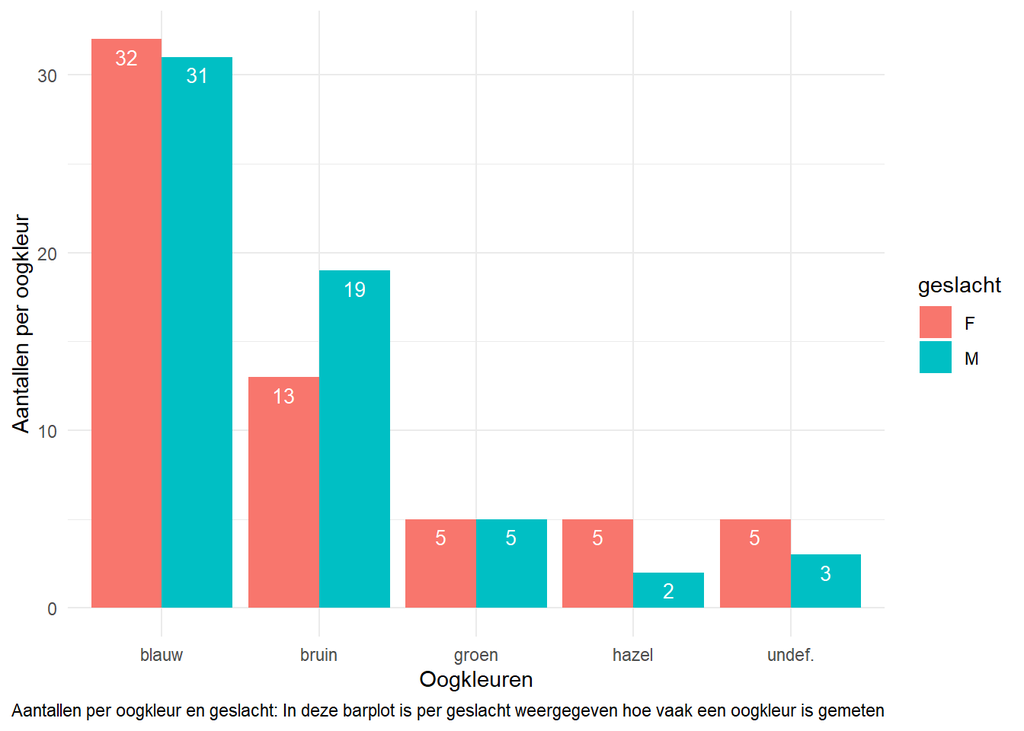

```r
library(ggplot2)
ggplot(data = male_female,
       mapping = aes(x = results, y = count, fill = geslacht)) +
  geom_bar(stat = "identity", position = position_dodge()) +
  geom_text(aes(label=count), vjust=1.6, color="white",
            position = position_dodge(0.9), size=3.5) +
  labs(caption = "Aantallen per oogkleur en geslacht: In deze barplot is per geslacht weergegeven hoe vaak een oogkleur is gemeten") +
  xlab("Oogkleuren") +
  ylab("Aantallen per oogkleur") +
  theme_minimal()
```

## 02-06-2023 08:40 - 08:50 - ALL

Er is besproken wie welke taak gaat doen binnen het schrijven van het wetenschappelijke artikel. Daarnaast is nog centraal besproken hoe iedereen ervoor staat.

## 02-06-2023 09:00 - 11:30 - 415069 (Demi van ’t Oever)

Er is gewerkt aan het beantwoorden van deelvraag 1. Hierbij is vooral gekeken naar welke statistische test erbij past (Chi-square test) en hoe deze het beste uit te voeren is bij deze vraag. Uiteindelijk is gekozen dit te doen middels een CrossTable.

```r
male_female2 <- eye_colors %>%
    rowwise() %>%
    mutate(results = majority2(c_across(4:11)))

library(gmodels)

CrossTable(male_female2$geslacht, male_female2$results, chisq = TRUE, expected = TRUE, format = "SPSS")
```

```
##
##    Cell Contents
## |-------------------------|
## |                   Count |
## |         Expected Values |
## | Chi-square contribution |
## |             Row Percent |
## |          Column Percent |
## |           Total Percent |
## |-------------------------|
##
## Total Observations in Table:  120
##
##                       | male_female2$results
## male_female2$geslacht |    blauw  |    bruin  |    groen  |    hazel  |   undef.  | Row Total |
## ----------------------|-----------|-----------|-----------|-----------|-----------|-----------|
##                     F |       32  |       13  |        5  |        5  |        5  |       60  |
##                       |   31.500  |   16.000  |    5.000  |    3.500  |    4.000  |           |
##                       |    0.008  |    0.562  |    0.000  |    0.643  |    0.250  |           |
##                       |   53.333% |   21.667% |    8.333% |    8.333% |    8.333% |   50.000% |
##                       |   50.794% |   40.625% |   50.000% |   71.429% |   62.500% |           |
##                       |   26.667% |   10.833% |    4.167% |    4.167% |    4.167% |           |
## ----------------------|-----------|-----------|-----------|-----------|-----------|-----------|
##                     M |       31  |       19  |        5  |        2  |        3  |       60  |
##                       |   31.500  |   16.000  |    5.000  |    3.500  |    4.000  |           |
##                       |    0.008  |    0.562  |    0.000  |    0.643  |    0.250  |           |
##                       |   51.667% |   31.667% |    8.333% |    3.333% |    5.000% |   50.000% |
##                       |   49.206% |   59.375% |   50.000% |   28.571% |   37.500% |           |
##                       |   25.833% |   15.833% |    4.167% |    1.667% |    2.500% |           |
## ----------------------|-----------|-----------|-----------|-----------|-----------|-----------|
##          Column Total |       63  |       32  |       10  |        7  |        8  |      120  |
##                       |   52.500% |   26.667% |    8.333% |    5.833% |    6.667% |           |
## ----------------------|-----------|-----------|-----------|-----------|-----------|-----------|
##
##
## Statistics for All Table Factors
##
##
## Pearson's Chi-squared test
## ------------------------------------------------------------
## Chi^2 =  2.926587     d.f. =  4     p =  0.5701851
##
##
##
##        Minimum expected frequency: 3.5
## Cells with Expected Frequency < 5: 4 of 10 (40%)
```

## 05-06-2023 09:15 - 10:30 - 415069 (Demi van ’t Oever)

Eerst is verder gewerkt aan de opmaak van de log. De chunks hebben labels gekregen en tabellen en figuren labels.

## 05-06-2023 11:00 - 11:20 - 415069 (Demi van ’t Oever)

Beschrijvende statistiek: Er zijn 120 proefpersonen gebruikt tijdens het onderzoek. Hiervan zijn 60 proefpersonen man en 60 proefpersonen vrouw. In tabel 1 is te zien bij hoeveel proefpersonen een bepaalde oogkleur gemeten is. Bij de proefpersonen waar geen eenduidig antwoord is gevonden doordat er geen meerderheid is, is de uitslag “undefined” gebleven.

Het toepassen van beschrijvende statistiek op onze dataset is verder lastig, omdat we niet met getallen werken maar met oogkleuren. Er kan echter wel aan de hand van de data gezegd worden dat de meerderheid van de proefpersonen (> 50%) blauwe ogen heeft, namelijk 32 vrouwen en 31 mannen. Bruin is de kleur die daarop volgt in prevalentie met 13 vrouwen en 19 mannen. Groen volgt daarna met 5 mannen en 5 vrouwen. Tot slot hazel met 5 vrouwen en 2 mannen.

## 05-06-2023 11:20 - 12:00 - 415069 (Demi van ’t Oever)

Discussie: Uit de crosstable is een p-waarde gekomen van 0.57. We hebben een α van 0.05 bij een 95% betrouwbaarheidsinterval. De p-waarde valt ver boven de α van 0.05 en dat betekent dat er geen significant verschil is in de prevalentie van oogkleuren tussen mannen en vrouwen. In tabel 1 en de barplot is ook te zien dat er weinig verschil zit in de aantallen van de oogkleuren tussen man en vrouw, alleen bij bruin lijkt er een verschil te zijn. Dit verschil is echter klein genoeg om geen significant verschil te vormen.

Conclusie: Bij een lage p-waarde, kan H0 verworpen worden. Onze p-waarde is echter niet laag en ligt boven de α van 0.05. Dit betekent dat H0 aangenomen kan worden: er is geen aantoonbaar verschil in oogkleur tussen mannen en vrouwen.

## 07-06-2023 09:40 - 09:45 - 415069 (Demi van ’t Oever)

De test die is gebruikt om de deelvraag te kunnen beantwoorden, is de Chi-squarte test. Deze test is niet gebruikt middels de chisq.test zelf, maar via een CrossTable. Voor deze CrossTable is gekozen omdat de data die gebruikt is voor de test netjes in de CrossTable staat, waardoor het overzichtelijker is. Daarnaast bleek de chisq.test zelf niet fijn in gebruik: het was lastig te zien of de juiste waarden op de juiste plek stonden. Door bij de CrossTable de Chi-square test aan te zetten, kan deze functie de test ook uitvoeren. Hiervoor is tevens het boek ‘Discovering Statistics Using R’ van Andy Field.

## 08-06-2023 14:00 - 15:30 - 415069 (Demi van ’t Oever)

Begin gemaakt aan de spelling- en grammaticacontrole van het bestand scientific_paper.Rmd. Tevens de studenten die bezig waren met resultaten beschrijven in de paper met hoe ze alles konden verwoorden.

## 09-06-2023 12:30 - 15:15 - 415069 (Demi van ’t Oever)

Verder gegaan met spelling- en grammaticacontrole van het bestand scientific_paper.Rmd. Dit is gedaan met behulp van onder andere Microsoft Word en ChatGPT.

## 09-06-2023 15:15 - 15:35 - ALL

Teamsmeating over de stand van zaken van de paper. We hebben besproken hoe ver iedereen is, wat er nog gedaan moet worden. Deze taken zijn verdeeld.

## 10-06-2023 10:00 - 13:00 - 415069 (Demi van ’t Oever)

Problemen in het document oplossen, mogelijk maken van knitten met LaTEX naar pdf. Evenals een probleem met het alfa-teken opgelost. Daarna verder gegaan met de spelling- en grammaticacontrole.

## 12-06-2023 09:45 - 15:30 - 415069 (Demi van ’t Oever)

Verder met de spelling- en grammaticacontrole van het bestand. Discussie en conclusie omgedraaid, deze stonden in de verkeerde volgorde. Hierdoor moesten zowel discussie als conclusie herschreven worden. Deze stukken heb ik herschreven en daarna opnieuw een spelling- en grammaticacontrole op uitgevoerd. Ondertussen meerdere besprekingen over wat er nog gedaan moet worden, nieuwe taakverdeling en stand van zaken bespreken.